# Tugas Pertemuan 4

Zanira Husna G1401231097

2025-09-15

# White Noise

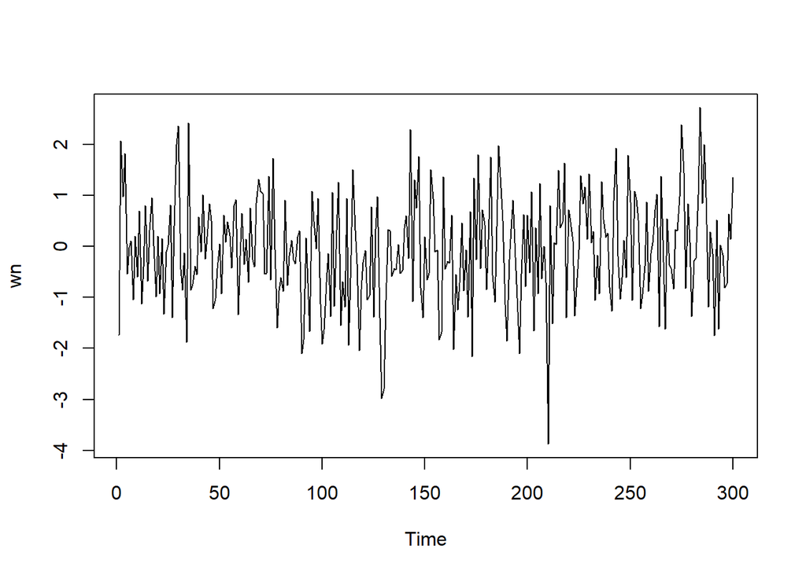

```r
set.seed(097)
wn <- rnorm(300)
ts.plot(wn)
```

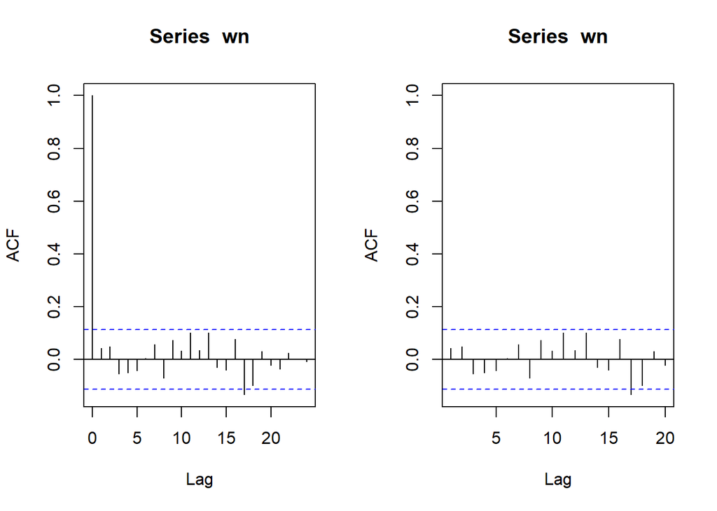

```r
par(mfrow = c(1, 2))
acf(wn)
acf(wn, xlim = c(1, 20))
```

# MA (2)

## Pembangkitan Proses MA(2)

Bangkitkan model MA(2) dengan θ1 = 0.4 dan θ2 = 0.6 sebanyak 300 data (Manual dan dengan arima.sim)

```r
set.seed(97)
n <- 300
theta1 <- 0.4
theta2 <- 0.6
mu <- 0
ma2_manual <- numeric(n)
```

```r
for (t in 3:n) {
  ma2_manual[t] <- mu + wn[t] + theta1 * wn[t - 1] + theta2 * wn[t - 2]
}
ma2_manual
```

```
##   [1]  0.00000000  0.00000000  0.76169972  3.45352835  0.77808379  0.85548694
##   [7] -0.22759183 -1.01453508 -0.15871681 -1.14817248  0.57049234 -1.21128307
##  [13] -0.43737521 -0.03798019 -0.59943632  0.52471574  0.67491873  0.58753576
##  [19] -0.40935026 -0.18280803 -1.43672231 -0.10061058 -1.82072969 -0.54836715
##  [25] -0.81743092  0.75308508 -1.05644260  0.32242087  1.31846898  3.39213993
##  [31]  1.69555169  0.37833913 -0.73773344 -2.44294873  1.59264617 -1.01852451
##  [37]  0.36739134 -1.20086134 -1.14956859  0.11942686 -0.21122305  1.31124864
##  [43]  0.09739315  0.69850952  0.76264837  0.95118439 -0.51406117 -1.20098734
##  [49] -1.56714215 -0.73811152 -1.16285060  0.27021551 -0.22331198  0.88256141
##  [55]  0.45319756 -0.05173370  0.75001149  0.97455653 -0.49737403 -0.17080615
##  [61] -0.23079903 -0.20530293  0.38779748 -0.86373126  0.55232928 -0.38196774
##  [67] -0.05512082  0.53429995  1.41230120  2.11306989  2.24945799  0.52407481
##  [73] -0.12324599  0.84522294 -0.42095151  2.28635859  0.23933834 -0.58306580
##  [79] -1.53673067 -1.91655270 -1.64135356  0.18823875 -0.92728705  0.05041368
##  [85] -0.41597581 -0.32690665 -0.37549298 -0.09932439  0.17385017 -1.86671777
```

[output cut: 35 more lines]

Dengan fungsi `arima.sim()` sebagai berikut.

```r
set.seed(97)
ma2_arima <- arima.sim(model = list(ma = c(0.4, 0.6)), n = 300)
ma2_arima
```

```
## Time Series:
## Start = 1
## End = 300
## Frequency = 1
##   [1]  0.76169972  3.45352835  0.77808379  0.85548694 -0.22759183 -1.01453508
##   [7] -0.15871681 -1.14817248  0.57049234 -1.21128307 -0.43737521 -0.03798019
##  [13] -0.59943632  0.52471574  0.67491873  0.58753576 -0.40935026 -0.18280803
##  [19] -1.43672231 -0.10061058 -1.82072969 -0.54836715 -0.81743092  0.75308508
##  [25] -1.05644260  0.32242087  1.31846898  3.39213993  1.69555169  0.37833913
##  [31] -0.73773344 -2.44294873  1.59264617 -1.01852451  0.36739134 -1.20086134
##  [37] -1.14956859  0.11942686 -0.21122305  1.31124864  0.09739315  0.69850952
##  [43]  0.76264837  0.95118439 -0.51406117 -1.20098734 -1.56714215 -0.73811152
##  [49] -1.16285060  0.27021551 -0.22331198  0.88256141  0.45319756 -0.05173370
##  [55]  0.75001149  0.97455653 -0.49737403 -0.17080615 -0.23079903 -0.20530293
##  [61]  0.38779748 -0.86373126  0.55232928 -0.38196774 -0.05512082  0.53429995
```

[output cut: 39 more lines]

## Karakteristik MA(2)

Buat plot time series, plot ACF, plot PACF dan plot EACF. Idenifikasi apakah data tersebut stasioner

### Plot Time Series

```r
library(TSA)
```

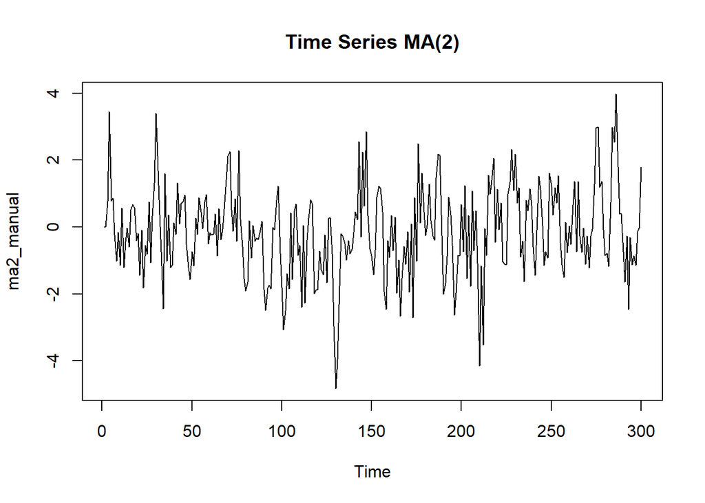

```r
ts.plot(ma2_manual, main = "Time Series MA(2)")
```

Berdasarkan plot time series, terlihat bahwa data MA(2) yang dibangkitkan stasioner dalam rataan

### Plot ACF

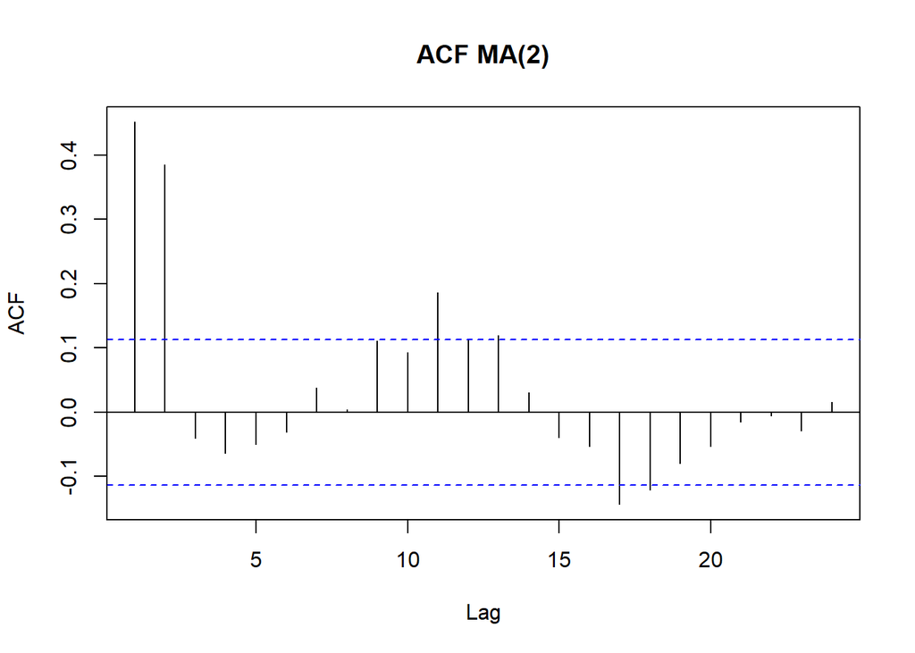

```r
acf(ma2_manual, main = "ACF MA(2)")
```

Berdasarkan plot ACF tersebut, terlihat bahwa plot ACF *cuts off* setelah lag 2

### Plot PACF

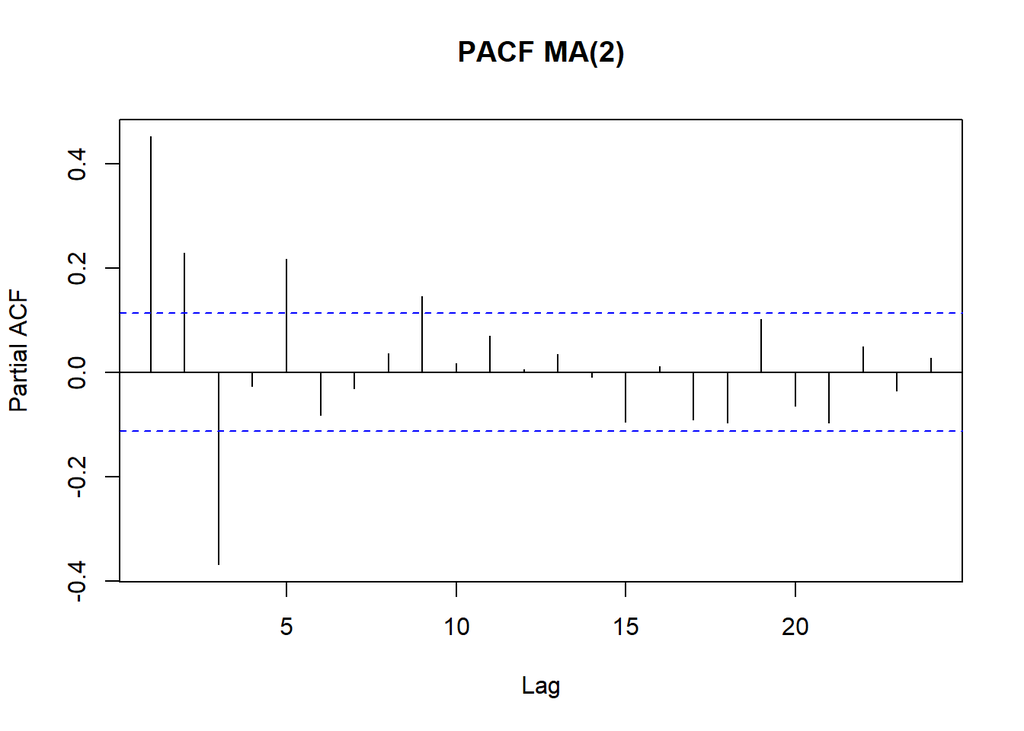

```r
pacf(ma2_manual, main = "PACF MA(2)")
```

Berdasarkan plot PACF tersebut, terlihat bahwa plot PACF cenderung *tails off* dan membentuk gelombang sinus

### Plot EACF

```r
eacf(ma2_manual)
```

```
## AR/MA
##   0 1 2 3 4 5 6 7 8 9 10 11 12 13
## 0 x x o o o o o o o o x  o  x  o
## 1 x x x o o o o o x o x  o  o  o
## 2 x x x o o o o o o o x  o  o  o
## 3 o x x o x o o o o o o  o  o  o
## 4 x x x o x o o o o o o  o  o  o
## 5 x x o o o x x o o o o  o  o  o
## 6 x x o o o x x x o o o  o  o  o
## 7 x x o x x o o x o o o  o  o  o
```

Berdasarkan pola segitiga nol pada plot EACF, terlihat bahwa segitiga nol berada pada ordo AR(0) dan ordo MA(2)

```r
library(tseries)
adf.test(ma2_manual)  # Jika p-value < 0.05, data stasioner
```

```
##
##  Augmented Dickey-Fuller Test
##
## data:  ma2_manual
## Dickey-Fuller = -6.3003, Lag order = 6, p-value = 0.01
## alternative hypothesis: stationary
```

pvalue < 0,05, dapat disimpulkan data stationer

## Scatterplot Antar Lag

Buat scatterplot antara Yt dengan Yt−1, Yt dengan Yt−2 serta Yt dengan Yt−3

```r
df <- data.frame(
  Yt = ma2_manual[4:n],
  Yt_1 = ma2_manual[3:(n-1)],
  Yt_2 = ma2_manual[2:(n-2)],
  Yt_3 = ma2_manual[1:(n-3)]
)
```

### Korelasi antara $Y_t$ dengan $Y_{t-1}$

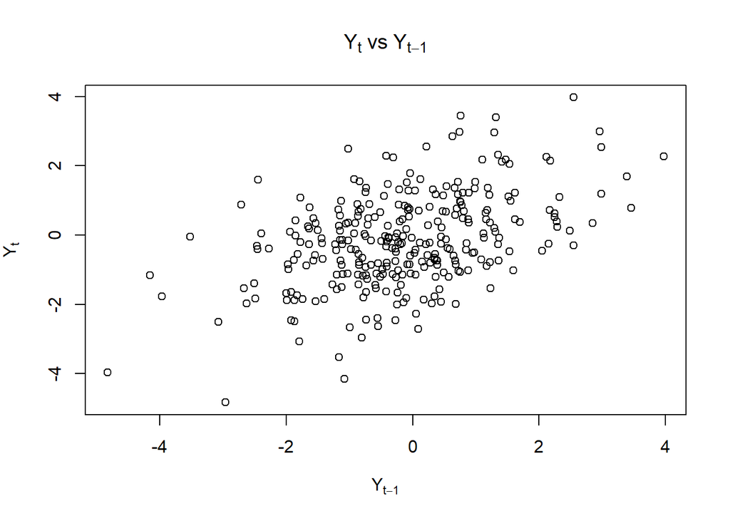

```r
plot(df$Yt_1, df$Yt, main = expression(Y[t]~vs~Y[t-1]), xlab = expression(Y[t-1]), ylab = expression(Y[t]))
```

Berdasarkan scatterplot tersebut, terlihat bahwa terdapat hubungan positif antara $Y_t$ dengan $Y_{t-1}$. Hal ini sesuai dengan teori yang ada

```r
cor(df$Yt_1,df$Yt)
```

```
## [1] 0.4529304
```

Korelasi antara $Y_t$ dengan $Y_{t-1}$ dari hasil simulasi mendekati perhitungan teoritis yaitu

$$\rho_1=\frac{\theta_{1}+\theta_{1}\theta_{2}}{1+\theta_{1}^2+\theta_{2}^2}=\frac{0.4+0.4⋅0.6}{1+0.4^2+0.6^2}=0.42$$

### Korelasi antara $Y_t$ dengan $Y_{t-2}$

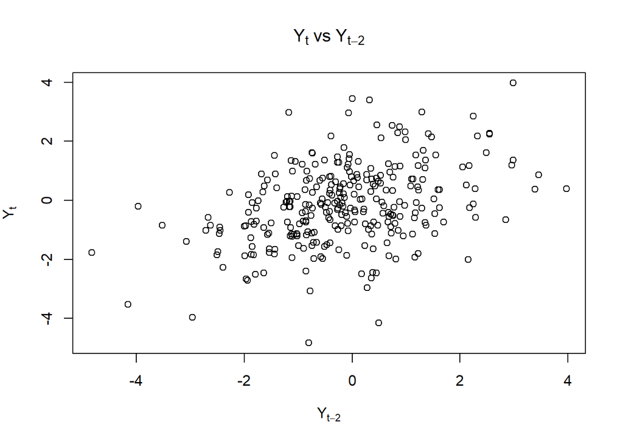

```r
plot(df$Yt_2, df$Yt, main = expression(Y[t]~vs~Y[t-2]), xlab = expression(Y[t-2]), ylab = expression(Y[t]))
```

Berdasarkan scatterplot tersebut, terlihat bahwa terdapat hubungan positif antara $Y_t$ dengan $Y_{t-2}$.

```r
cor(df$Yt_2, df$Yt)
```

```
## [1] 0.3868653
```

Korelasi antara $Y_t$ dengan $Y_{t-2}$ hasil simulasi mendekati teori yang ada yaitu 0.3947

### Korelasi antara $Y_t$ dengan $Y_{t-3}$

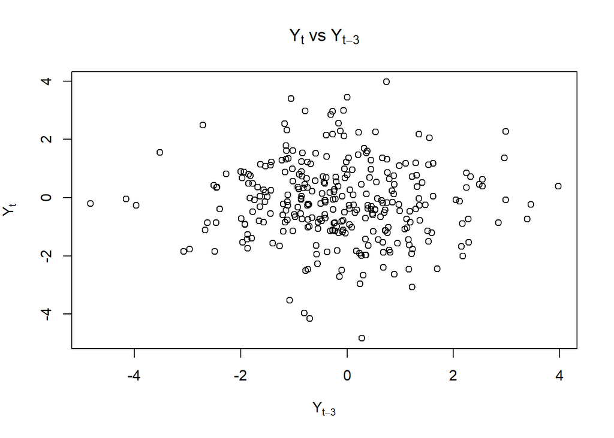

```r
plot(df$Yt_3, df$Yt, main = expression(Y[t]~vs~Y[t-3]), xlab = expression(Y[t-3]), ylab = expression(Y[t]))
```

Berdasarkan scatterplot tersebut, terlihat bahwa cenderung tidak terdapat hubungan antara Yt dengan Yt−3. sebaran mengikuti garis horizontal 0

## Autokorelasi

Hitung autokorelasi masing masing baik dari data bangkitan maupun secara teoritis

Dari data

```r
# Asumsikan data sudah tersedia:
# ma2_manual <- ... (data hasil simulasi)

# Hitung autokorelasi hingga lag ke-5
acf_result <- acf(ma2_manual, lag.max = 5, plot = FALSE)

# Ambil nilai ACF untuk lag 1 sampai 5
acf_values <- acf_result$acf[2:6]  # [1] adalah lag 0 (selalu 1)

# Tampilkan hasil
lag <- 1:5
data.frame(Lag = lag, Autokorelasi = round(acf_values, 4))
```

[output not shown]

```r
# Parameter
theta1 <- 0.4
theta2 <- 0.6

denom <- 1 + theta1^2 + theta2^2
rho1 <- (theta1 + theta1 * theta2) / denom
rho2 <- theta2 / denom
rho3 <- 0

# Tampilkan
cat("Teoretis:\n")
```

```
## Teoretis:
```

```r
cat("rho(1) =", round(rho1, 4), "\n")
```

```
## rho(1) = 0.4211
```

```r
cat("rho(2) =", round(rho2, 4), "\n")
```

```
## rho(2) = 0.3947
```

```r
cat("rho(3) =", round(rho3, 4), "\n")
```

```
## rho(3) = 0
```

# Proses AR(2)

## Pembangkitan Proses AR

Bangkitkan model AR(2) dengan φ1 = 0.5 dan φ2 = 0.2 sebanyak 300 data (Manual dan dengan arima.sim)

```r
# Set seed
set.seed(97)

# Parameter AR(2)
phi1 <- 0.5
phi2 <- 0.2
n <- 300
sigma <- 1
```

```r
e <- rnorm(n, mean = 0, sd = 1)  # white noise
y_manual <- numeric(n)
y_manual[1:2] <- e[1:2]  # initial values

for (t in 3:n) {
  y_manual[t] <- phi1 * y_manual[t-1] + phi2 * y_manual[t-2] + e[t]
}
y_manual
```

```
##   [1] -1.737687755  2.065966439  1.663371467  3.067657186  1.328719929
##   [6]  1.254824630  0.997460953 -0.292721471  0.248798608 -0.535134208
##  [11]  0.475680350 -0.997271296 -0.805733575  0.197443141 -0.740426738
##  [16] -0.014666880  0.799877753  0.412787928 -0.622471644 -0.025419257
##  [21] -1.061925160 -0.388723916 -1.731572965 -1.050361539 -0.851298589
##  [26]  0.173382930 -1.475770731 -0.309369635  1.546415841  3.068668515
##  [31]  1.398482427  0.454967335  0.379730741 -1.596305576  1.697774943
##  [36] -0.330592141 -0.566251294 -0.737770234 -1.031987377 -0.091064381
##  [41] -0.362234857  0.812550397  0.092652214  0.396687686  1.049087664
##  [46]  1.109469513 -0.451072165 -1.021732624 -1.031612042 -0.675197282
##  [51] -1.466434982 -0.256009026 -0.335994303  0.261894816  0.273330273
##  [56] -0.235178551  0.731028291  1.229987954 -0.577149107 -0.224949323
##  [61]  0.417254678 -0.190305699  0.130577343 -0.681049525  0.435863255
##  [66] -0.175388804 -0.402961889  0.612983616  1.539847779  1.970285774
##  [71]  2.323095357  1.021027385  0.447728008  1.805000792  0.336764816
```

[output cut: 45 more lines]

pembangkitan proses AR2 dengan fungsi `arima.sim()` sebagai berikut.

```r
y_arima <- arima.sim(n = n, model = list(ar = c(phi1, phi2)))
y_arima
```

```
## Time Series:
## Start = 1
## End = 300
## Frequency = 1
##   [1]  0.118576588 -0.771980336 -0.437398530 -1.618064617 -1.928745570
##   [6] -0.575150674 -1.422864613 -0.326731011 -2.583194121 -2.563238924
##  [11] -1.052564580 -0.826864952 -1.574187345 -2.212024271 -2.059823767
##  [16] -0.363456154 -1.514961601 -0.516568687 -0.374707872 -0.921333063
##  [21] -0.039830070  1.406558266  1.932005995  1.338179974  1.433774108
##  [26]  0.882950928 -0.020672285 -0.214968354 -0.215458198 -1.780182235
##  [31] -0.265661113 -0.322110063 -2.060924784 -0.210291649  0.184040245
##  [36] -0.262426953 -0.048382507 -0.284179886  0.081991604 -1.079411982
##  [41] -0.301963077 -1.195667597 -1.640540493 -1.247162545 -2.338161112
##  [46] -1.381668473 -0.639038122 -0.876220427 -1.154185149 -0.017253875
##  [51] -0.497208835 -0.888126065  0.269214726  1.931740174  1.608534374
```

[output cut: 49 more lines]

## Karakteristik AR(2)

### Plot Time Series

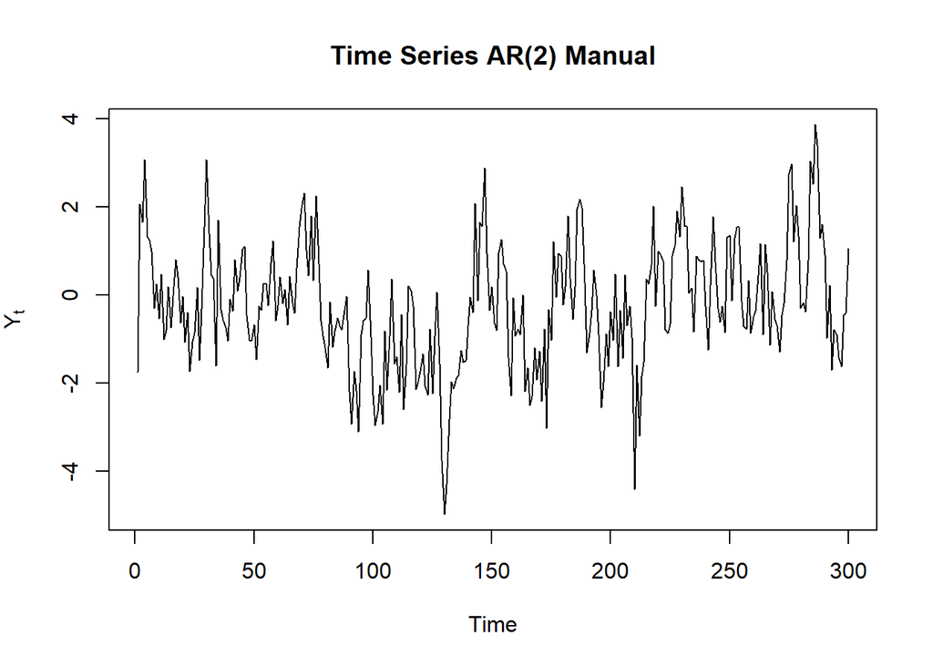

```r
ts.plot(y_manual, main="Time Series AR(2) Manual", ylab=expression(Y[t]))
```

Berdasarkan plot time series tersebut terlihat bahwa data cenderung stasioner pada rataan

### Plot ACF

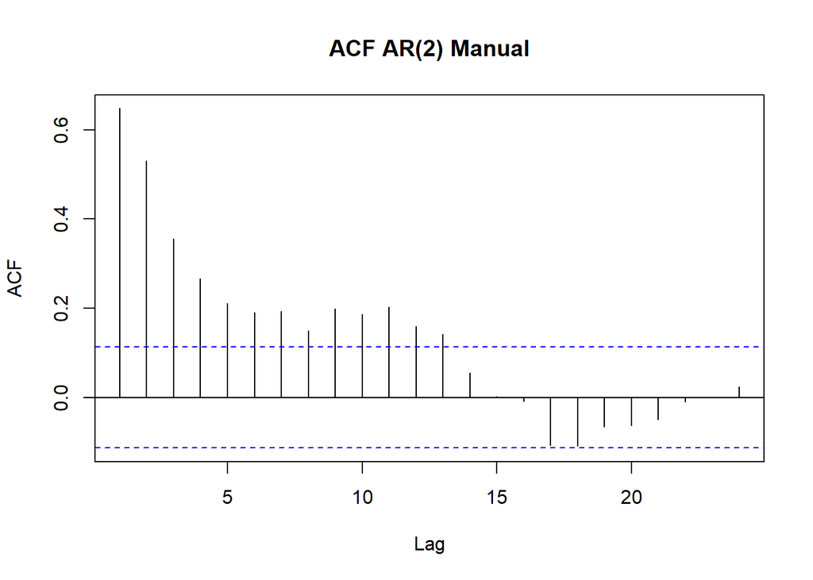

```r
acf(y_manual, main="ACF AR(2) Manual")
```

Berdasarkan plot ACF tersebut terlihat bahwa plot ACF cenderung *tails off*

### Plot PACF

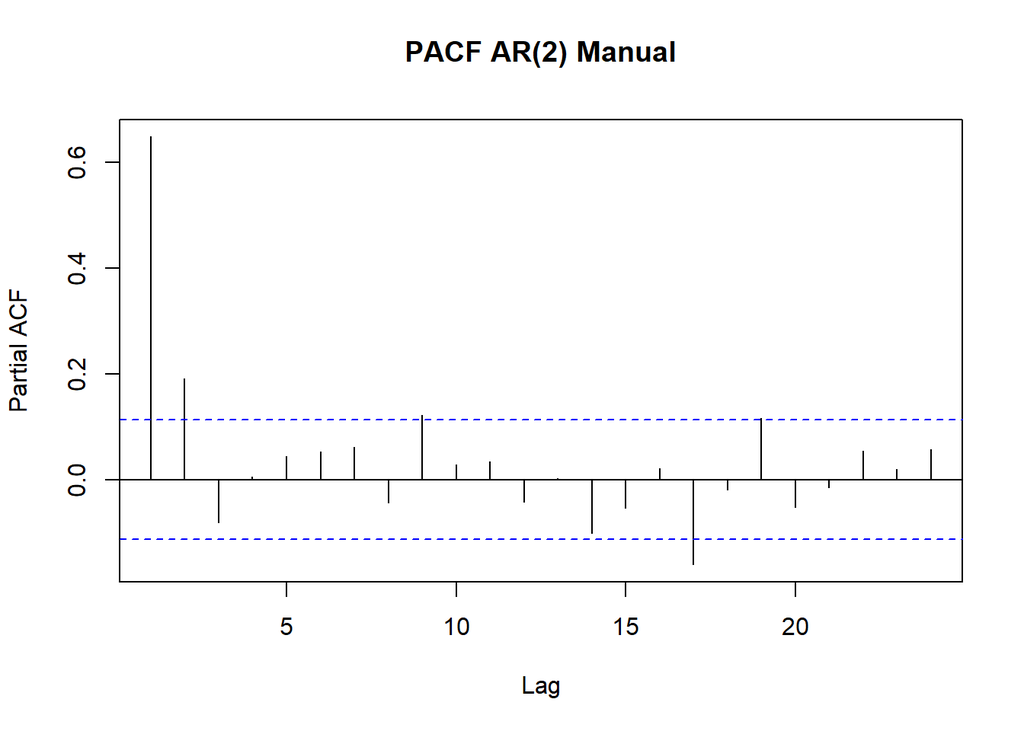

```r
pacf(y_manual, main="PACF AR(2) Manual")
```

### Plot EACF

```r
eacf(y_manual)
```

```
## AR/MA
##   0 1 2 3 4 5 6 7 8 9 10 11 12 13
## 0 x x x x x x x x x x x  x  x  o
## 1 x x o o o o o o o o o  o  x  o
## 2 x o o o o o o o o o o  o  x  o
## 3 o x o o o o o o o o o  o  x  o
## 4 o x o o o o o o o o o  o  o  o
## 5 x o o o o o o x o o o  o  o  o
## 6 x o o o x o o x o o o  o  o  o
## 7 x x x x o x o o o o o  o  o  o
```

```r
adf.test(y_manual)  # Jika p-value < 0.05, data stasioner
```

```
##
##  Augmented Dickey-Fuller Test
##
## data:  y_manual
## Dickey-Fuller = -4.4702, Lag order = 6, p-value = 0.01
## alternative hypothesis: stationary
```

pvalue < 0,05, dapat disimpulkan data stationer

### Scatterplot Antar Lag

#### Korelasi antara $Y_t$ dengan $Y_{t-1}$

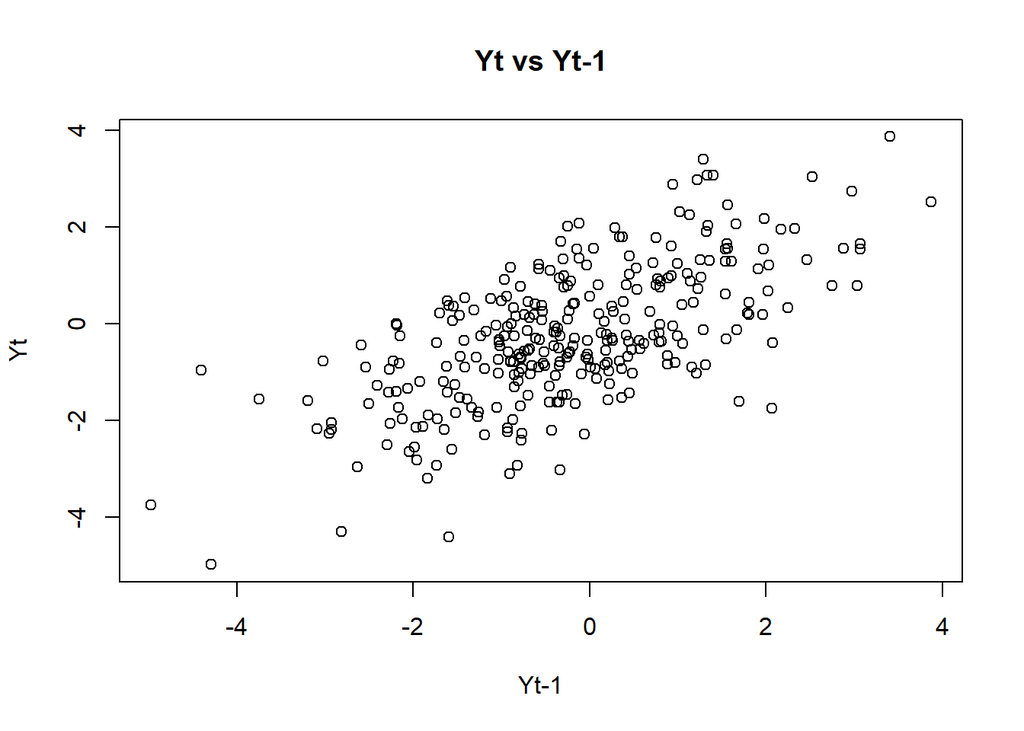

```r
plot(y_manual[2:n], y_manual[1:(n-1)],
     xlab = "Yt-1", ylab = "Yt", main = "Yt vs Yt-1")
```

Berdasarkan scatterplot tersebut, terlihat bahwa terdapat hubungan positif antara $Y_t$ dengan $Y_{t-1}$. Hal ini sesuai dengan teori yang ada

```r
cor(y_manual[2:n], y_manual[1:(n-1)])
```

```
## [1] 0.6499529
```

Korelasi antara $Y_t$ dengan $Y_{t-1}$ dari hasil simulasi cukup jauh dari perhitungan teoritis yaitu $\rho_1=\phi^1=0.38095$

#### Korelasi antara $Y_t$ dengan $Y_{t-2}$

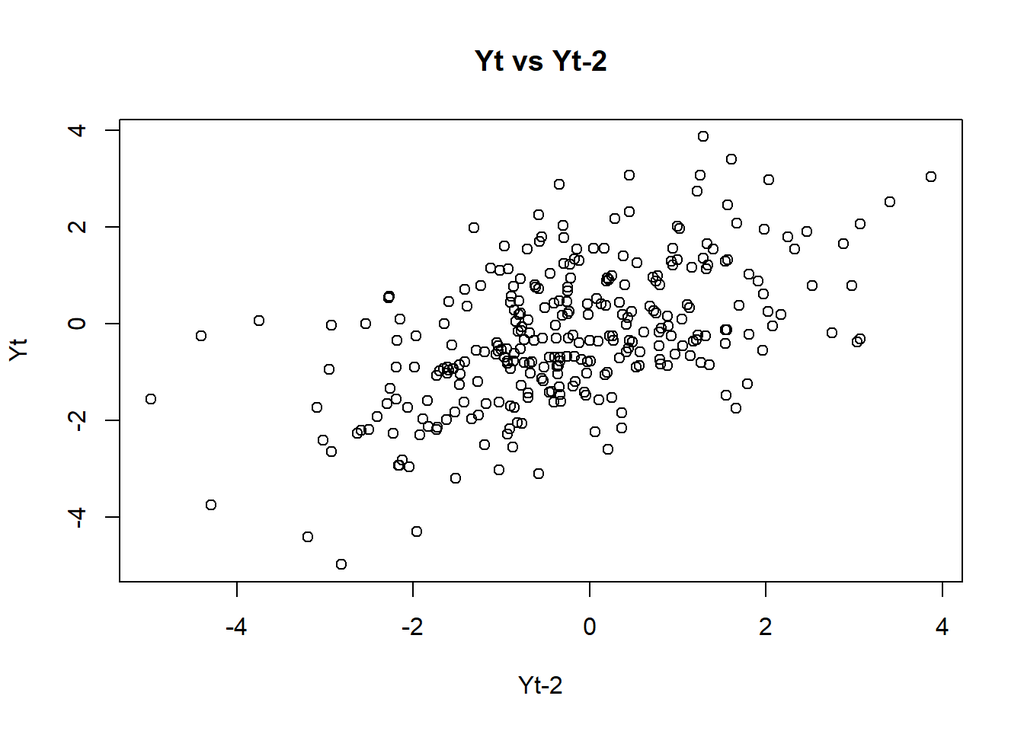

```r
plot(y_manual[3:n], y_manual[1:(n-2)],
     xlab = "Yt-2", ylab = "Yt", main = "Yt vs Yt-2")
```

Berdasarkan scatterplot tersebut, terlihat bahwa terdapat hubungan positif antara $Y_t$ dengan $Y_{t-2}$. Hal ini sesuai dengan teori yang ada

```r
cor(y_manual[3:n], y_manual[1:(n-2)])
```

```
## [1] 0.5345548
```

Korelasi antara $Y_t$ dengan $Y_{t-2}$ dari hasil simulasi cukup jauh dari perhitungan teoritis yaitu $\rho_2=\phi^2=0.390475$.

### Korelasi antara $Y_t$ dengan $Y_{t-3}$

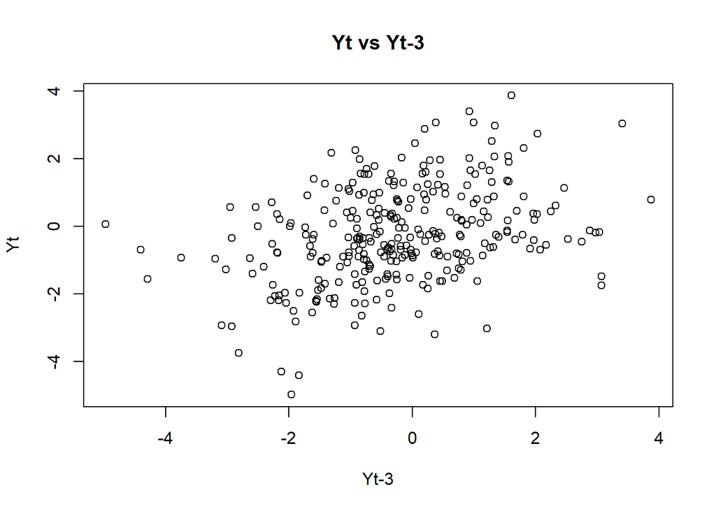

```r
plot(y_manual[4:n], y_manual[1:(n-3)],
     xlab = "Yt-3", ylab = "Yt", main = "Yt vs Yt-3")
```

Berdasarkan scatterplot tersebut, terlihat bahwa terdapat hubungan positif antara $Y_t$ dengan $Y_{t-2}$. Hal ini sesuai dengan teori yang ada

```r
cor(y_manual[4:n], y_manual[1:(n-3)])
```

```
## [1] 0.3601882
```

```r
# Parameter
phi1 <- 0.5
phi2 <- 0.2
rho <- numeric(10)

# Hitung rho_1 dan rho_2
rho[1] <- (phi1 * (1 - phi2)) / (1 - phi2 + phi1^2)
rho[2] <- phi1 * rho[1] + phi2

# Rekursif untuk rho_3 sampai rho_10
for (k in 3:10) {
  rho[k] <- phi1 * rho[k-1] + phi2 * rho[k-2]
}

# Tampilkan hasil
rho[1:5]
```

```
## [1] 0.3809524 0.3904762 0.2714286 0.2138095 0.1611905
```

## Autokorelasi

```r
acf_empirical <- acf(y_manual, plot = FALSE)
acf_empirical$acf[2:5]  # lag 1 sampai 4
```

[output not shown]

```r
# Fungsi untuk menghitung ACF teoritis
acf_theoretical <- numeric(10)
acf_theoretical[1] <- (phi1 * (1 - phi2)) / (1 - phi2 + phi1^2)
acf_theoretical[2] <- phi1 * acf_theoretical[1] + phi2

for (k in 3:10) {
  acf_theoretical[k] <- phi1 * acf_theoretical[k-1] + phi2 * acf_theoretical[k-2]
}

# Tampilkan
acf_theoretical[1:5]
```

```
## [1] 0.3809524 0.3904762 0.2714286 0.2138095 0.1611905
```

Hasil empiris dan teoritis cukup berbeda

# Fungsi pembangkitan ARMA

```r
set.seed(097)

n <- 300
phi <- c(0.5, 0.2)
theta <- c(0.4, 0.6)
e <- rnorm(n + 2)  # tambahkan 2 untuk lag

arma22 <- numeric(n + 2)

# Loop untuk ARMA(2,2)
for (t in 3:(n + 2)) {
  arma22[t] <- phi[1] * arma22[t - 1] + phi[2] * arma22[t - 2] +
          e[t] + theta[1] * e[t - 1] + theta[2] * e[t - 2]
}

arma22_manual <- arma22[3:(n + 2)]  # buang data awal
arma22_manual
```

```
##   [1]  0.7616997205  3.8343782074  2.8476128351  3.0461690035  1.8650152381
##   [6]  0.5272063445  0.4778894147 -0.8037865050  0.2641769676 -1.2399518843
##  [11] -1.0045157577 -0.7882284449 -1.1944536906 -0.2301567989  0.3209495914
##  [16]  0.7019791962  0.0058292537 -0.0394975617 -1.4553052362 -0.8361627091
##  [21] -2.5298720922 -1.9805357420 -2.3136732098 -0.7998586752 -1.9191065804
##  [26] -0.7971041525  0.5360955835  3.5007668911  3.5531542552  2.8550696372
##  [31]  1.4004322255 -1.1717186875  1.2868732713 -0.6094316138  0.3200501857
##  [36] -1.1627225718 -1.6669198404 -0.9465775761 -1.0178958059  0.6129852192
##  [41]  0.2003066014  0.9212598598  1.2633396207  1.7671061768  0.6221598427
##  [46] -0.5364861833 -1.7109532698 -1.7008853933 -2.3554839555 -1.2477035497
##  [51] -1.3182605506 -0.0261095771  0.1764906594  0.0312897169  0.8009544776
##  [56]  1.3812917153  0.3534627261  0.2821835606 -0.0190147031 -0.1583735648
##  [61]  0.3048077609 -0.7430020904  0.2417897875 -0.4096732654 -0.2115994949
##  [66]  0.3465655491  1.5432640706  2.9540150386  4.0351183215  3.1324369821
##  [71]  2.2499961685  2.5967084209  1.3274019336  3.4694012445  2.2395193463
```

[output cut: 45 more lines]

Pembangkitan ARMA(p,q) juga dapat dilakukan dengan fungsi `arima.sim` sebagai berikut.

```r
set.seed(097)
arma22_sim <- arima.sim(n = 300, model = list(ar = c(0.5, 0.2), ma = c(0.4, 0.6)))
arma22_sim
```

```
## Time Series:
## Start = 1
## End = 300
## Frequency = 1
##   [1] -0.7971041525  0.5360955835  3.5007668911  3.5531542552  2.8550696372
##   [6]  1.4004322255 -1.1717186875  1.2868732713 -0.6094316138  0.3200501857
##  [11] -1.1627225718 -1.6669198404 -0.9465775761 -1.0178958059  0.6129852192
##  [16]  0.2003066014  0.9212598598  1.2633396207  1.7671061768  0.6221598427
##  [21] -0.5364861833 -1.7109532698 -1.7008853933 -2.3554839555 -1.2477035497
##  [26] -1.3182605506 -0.0261095771  0.1764906594  0.0312897169  0.8009544776
##  [31]  1.3812917153  0.3534627261  0.2821835606 -0.0190147031 -0.1583735648
##  [36]  0.3048077609 -0.7430020904  0.2417897875 -0.4096732654 -0.2115994949
##  [41]  0.3465655491  1.5432640706  2.9540150386  4.0351183215  3.1324369821
##  [46]  2.2499961685  2.5967084209  1.3274019336  3.4694012445  2.2395193463
##  [51]  1.2305741237 -0.4735397374 -1.9072077458 -2.6896653804 -1.5380354934
```

[output cut: 49 more lines]

## Karakteristik ARMA(2,2)

### Plot Time Series

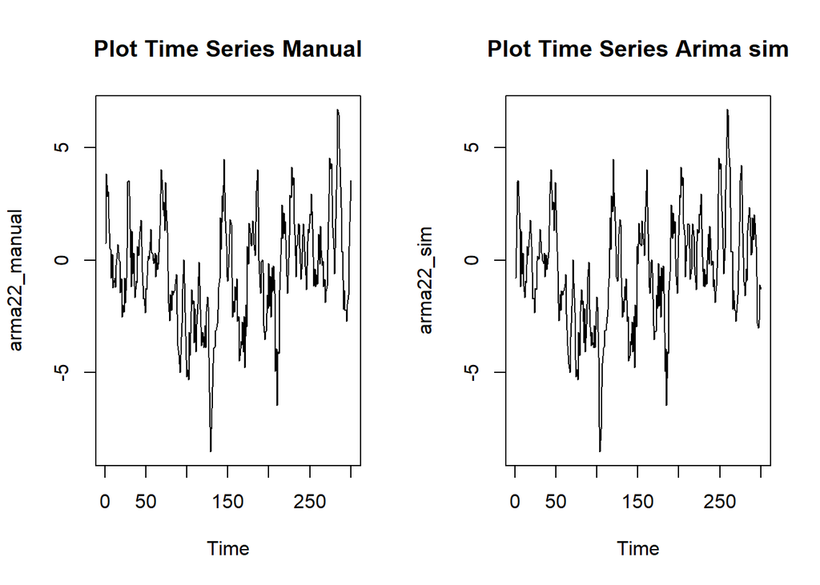

```r
par(mfrow = c(1, 2))
ts.plot(arma22_manual, main = "Plot Time Series Manual")
ts.plot(arma22_sim, main = "Plot Time Series Arima sim")
```

Berdasarkan plot time series tersebut, terlihat bahwa model ARMA(2,2) cenderung stasioner dalam rataan

### Plot ACF

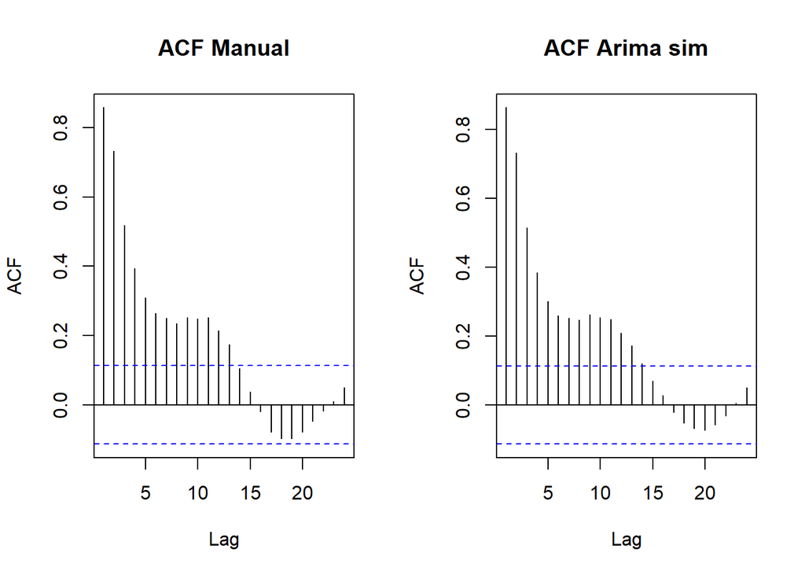

```r
par(mfrow = c(1, 2))
acf(arma22_manual, main = "ACF Manual")
acf(arma22_sim, main = "ACF Arima sim")
```

Berdasarkan plot ACF tersebut, terlihat bahwa model ARMA(2,2) hasil simulasi memiliki plot ACF yang *tails off*, sesuai dengan teori yang ada

### Plot PACF

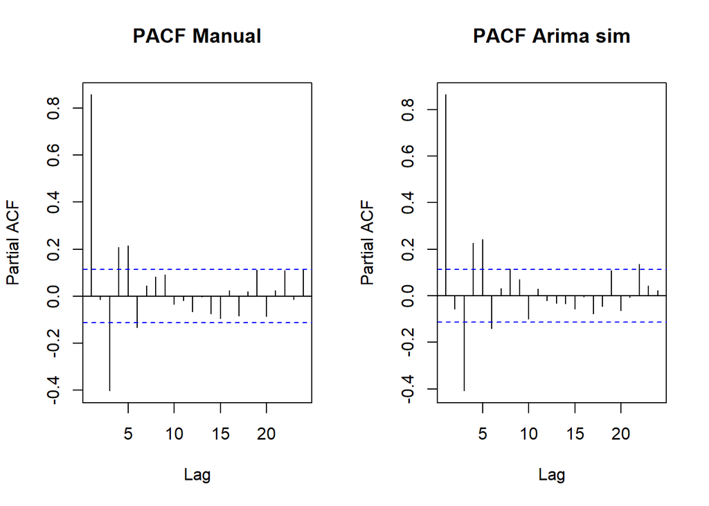

```r
par(mfrow = c(1, 2))
pacf(arma22_manual, main = "PACF Manual")
pacf(arma22_sim, main = "PACF Arima sim")
```

### Plot EACF

```r
eacf(arma22_sim)
```

```
## AR/MA
##   0 1 2 3 4 5 6 7 8 9 10 11 12 13
## 0 x x x x x x x x x x x  x  x  x
## 1 o x o o o x o o o o x  o  o  o
## 2 x x x o o x o o o o x  o  o  o
## 3 x x x o o o o o o o o  o  o  o
## 4 x x x o x o o o o o o  o  o  o
## 5 x x x x o x o o o o o  o  o  o
## 6 x x x x o x o o o o o  o  o  o
## 7 x x x x x x o x o o o  o  o  o
```

```r
adf.test(arma22_sim)
```

```
##
##  Augmented Dickey-Fuller Test
##
## data:  arma22_sim
## Dickey-Fuller = -4.2148, Lag order = 6, p-value = 0.01
## alternative hypothesis: stationary
```

pvalue < 0,05, dapat disimpulkan data stationer

### Scatterplot Antar Lag

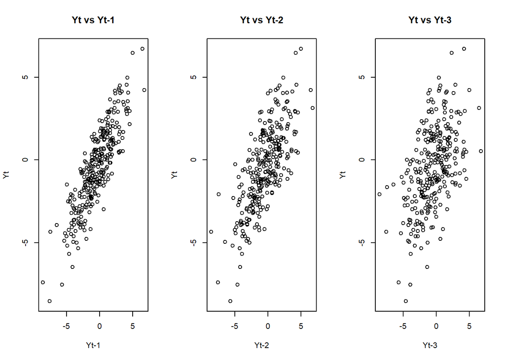

```r
par(mfrow = c(1, 3))  # 3 plot dalam 1 baris

plot(arma22_sim[2:300], arma22_sim[1:299], main = "Yt vs Yt-1", xlab = "Yt-1", ylab = "Yt")
plot(arma22_sim[3:300], arma22_sim[1:298], main = "Yt vs Yt-2", xlab = "Yt-2", ylab = "Yt")
plot(arma22_sim[4:300], arma22_sim[1:297], main = "Yt vs Yt-3", xlab = "Yt-3", ylab = "Yt")
```

di ketiga plot menunjukkan Yt memiliki hubungan positif yang cukup kuat dengan ketiga, Yt-1, Yt-2, Yt-3.

```r
# Korelasi Yt dengan Yt-1
cor_yt_yt1 <- cor(arma22_sim[2:300], arma22_sim[1:299])

# Korelasi Yt dengan Yt-2
cor_yt_yt2 <- cor(arma22_sim[3:300], arma22_sim[1:298])

# Korelasi Yt dengan Yt-3
cor_yt_yt3 <- cor(arma22_sim[4:300], arma22_sim[1:297])

# Tampilkan hasil
cat("Korelasi Yt dengan Yt-1:", cor_yt_yt1, "\n")
```

```
## Korelasi Yt dengan Yt-1: 0.8639768
```

```r
cat("Korelasi Yt dengan Yt-2:", cor_yt_yt2, "\n")
```

```
## Korelasi Yt dengan Yt-2: 0.7321207
```

```r
cat("Korelasi Yt dengan Yt-3:", cor_yt_yt3, "\n")
```

```
## Korelasi Yt dengan Yt-3: 0.5188707
```

## Autokorelasi

```r
acf(arma22_sim, lag.max = 10, plot = FALSE)
```

```
##
## Autocorrelations of series 'arma22_sim', by lag
##
##     1     2     3     4     5     6     7     8     9    10
## 0.864 0.732 0.516 0.385 0.301 0.259 0.253 0.247 0.263 0.253
```

```r
acf_theory <- ARMAacf(ar = c(0.5, 0.2), ma = c(0.4, 0.6), lag.max = 10)
print(acf_theory)
```

```
##          0          1          2          3          4          5          6
## 1.00000000 0.85919932 0.74919080 0.54643526 0.42305579 0.32081495 0.24501863
##          7          8          9         10
## 0.18667231 0.14233988 0.10850440 0.08272018
```

Hasil empiris dan teoritis cukup berbeda